# Exploratory Data Analysis - Week 2

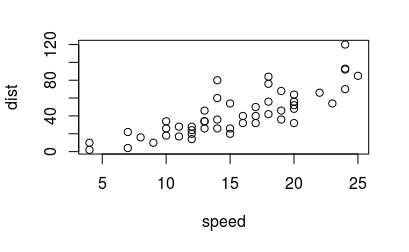

```r
plot(cars)
```

## Week 2

### The Lattice Plotting system

Implemented with the following packages:

- `lattice`
- `grid`

#### Main functions

- xyplot
- bwplot
- histogram
- stripplot
- dotplot
- splom
- levelplot / counterplot

#### xyplot

The function is used in the following way

`xyplot(y ~ x | f * g, data)`

- y is the y-axis variable
- x is the x-axis variable
- f and g, condition variables
- data is the data frame where the variables should be extracted from

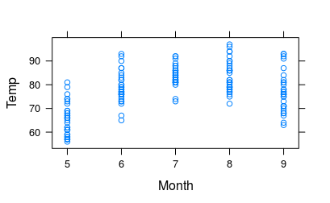

```r
library(lattice)
xyplot(Temp ~ Month, data = airquality)
```

Now converting the month variable into a factor

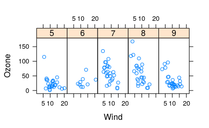

```r
library(datasets)
library(lattice)
airquality <- transform(airquality, Month = factor(Month))
xyplot( Ozone ~ Wind | Month, data = airquality, layout = c(5,1))
```

### Lattice Panel Functions

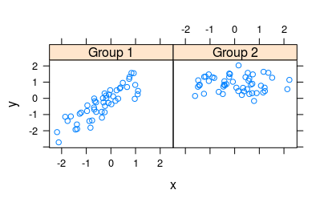

```r
set.seed(10)
x <- rnorm(100)
f <- rep(0:1, each=50)
y <- x + f - f * x + rnorm(100, sd = 0.5)
f <-factor(f, labels = c("Group 1", "Group 2"))
xyplot (y ~ x | f, layout = c(2,1))
```

#### Custom Panel function

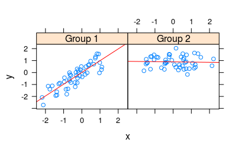

```r
xyplot (y ~ x | f, panel = function(x,y, ...) {
  panel.xyplot(x, y, ...) ## First call the default panel function for xyplot
  #panel.abline( h = median(y), lty = 2) ## Add a horizontal line at the median
  panel.lmline(x, y, col = 2)
})
```

### Working with colors (swirl)

We use the library grDevices:

```r
library(grDevices)
```

We can use the function colorRamp to return another function which will make a specific number of gradients.

`colorRampPalette` takes a palette of colros and returns a function.

```r
p1 <- colorRampPalette(c("red", "blue"))
p1(2) ## returns a vector of two colors
```

```
[1] "#FF0000" "#0000FF"
```

```r
p1(6) ## returns a vector of six colors
```

```
[1] "#FF0000" "#CC0033" "#990066" "#650099" "#3200CC" "#0000FF"
```

The brewer package contains different color palettes, from colors center to the white, to divergent to different. (colorblind?)

```r
cols<-brewer.pal(3, "BuGn")
```

```
Error in brewer.pal(3, "BuGn") : could not find function "brewer.pal"
```

### ggplot2

Implementation of the Grammar of Graphics

#### qplot() function

Looks for data in a data frame.

```r
library(ggplot2)
str(mpg)
```

```
Classes ‘tbl_df’, ‘tbl’ and 'data.frame':   234 obs. of  11 variables:
 $ manufacturer: chr  "audi" "audi" "audi" "audi" ...
 $ model       : chr  "a4" "a4" "a4" "a4" ...
 $ displ       : num  1.8 1.8 2 2 2.8 2.8 3.1 1.8 1.8 2 ...
 $ year        : int  1999 1999 2008 2008 1999 1999 2008 1999 1999 2008 ...
 $ cyl         : int  4 4 4 4 6 6 6 4 4 4 ...
 $ trans       : chr  "auto(l5)" "manual(m5)" "manual(m6)" "auto(av)" ...
 $ drv         : chr  "f" "f" "f" "f" ...
 $ cty         : int  18 21 20 21 16 18 18 18 16 20 ...
 $ hwy         : int  29 29 31 30 26 26 27 26 25 28 ...
 $ fl          : chr  "p" "p" "p" "p" ...
 $ class       : chr  "compact" "compact" "compact" "compact" ...
```

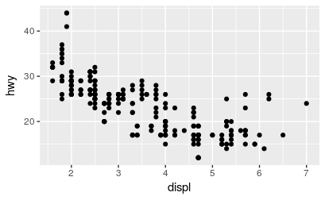

```r
qplot(displ, hwy, data=mpg)
```

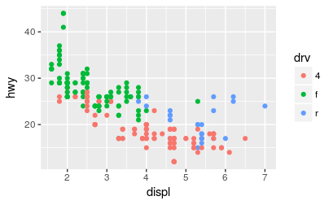

```r
qplot(displ, hwy, data=mpg, color = drv)
```

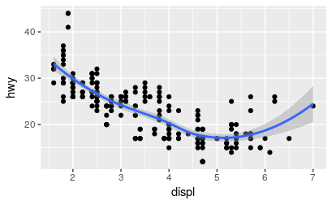

```r
qplot(displ, hwy, data=mpg, geom = c("point", "smooth"))
```

We can also get a histogram with qplot

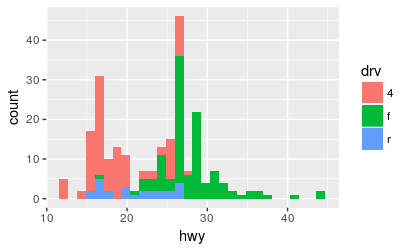

```r
qplot(hwy, data = mpg, fill = drv)
```

#### Facets

Facets are like panels in lattice

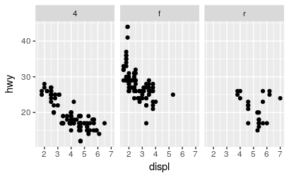

```r
qplot(displ, hwy, data = mpg, facets = . ~ drv)
```

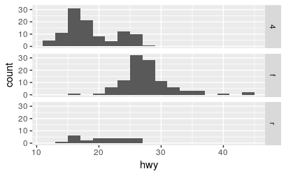

```r
qplot(hwy, data = mpg, facets = drv ~ ., binwidth = 2)
```

### ggplot2 part 2

Basic components of ggplot2 plot

- data frame
- aesthetic mappings
- geoms
- facets
- stats
- scales
- coordinate system

#### Building up in layers:

Labels:

- xlab()
- ylab()
- labs()
- ggtitle()

global theme:

theme(legend.position = “none”)

Two standard appearence themes are included:

- theme_gray(): default one with gray background.
- theme_bw()

`g + geom_point(aes(color = bmicat), size=4, alpha = 1/2))`

aes is aesthetics.

### ggplot2 part 5

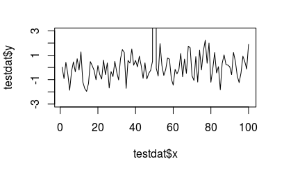

```r
library(ggplot2)
testdat <- data.frame(x = 1:100, y = rnorm(100))
testdat[50,2] <- 100 ## outlier
plot(testdat$x, testdat$y, type = "l", ylim = c(-3,3))
```

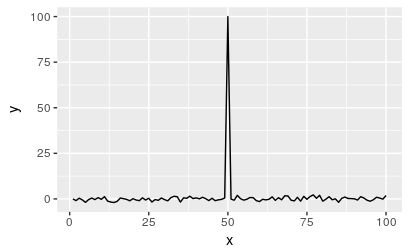

```r
g <- ggplot(testdat, aes(x = x, y = y))
g + geom_line()
```

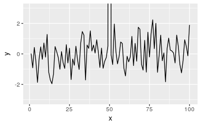

```r
g + geom_line() + coord_cartesian(ylim = c(-3,3))
```

#### Quantifying continuos variables

`cutpoints <- quantile(maacs$logno2_new, seq(0,1, length = 4), na.rm = TRUE)`

`maacs$no2dec <- cut(maac$logno2_new, cutpoints)`

See the levels of the newly created factor variable

`levels(maacs$no2dec)`

Final code of example:

```
g <- ggplot (maacs, aes(logpm24, NocturnalSympt))

## Add layers

g + geom_point(alpha = 1/3)
  + facet_wrap(bmicat ~no2dec, nrow = 2, ncol = 4)
  + geom_smooth(method = "lm", se=FALSE, col="steelblue")
  + theme_bw(base_family = "Avenir", base_size = 10)
  + labs(x = expression("log " * PM[2.5])
  + labs(y = "Nocturnal Symptoms")
  + labs(title = "MAACS Cohort")
```

#### ggplot2 exercises (I)

Using the mpg data provided by ggplot2 itself (I think…)

#### ggplot2 exercises (II)

We can build something similar step by step… let’s see:

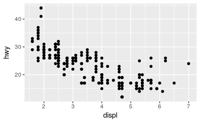

```r
g <- ggplot(mpg, aes(displ, hwy))
g+geom_point()
```

geom_point adds a layer.

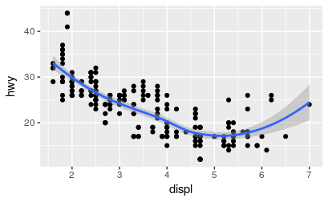

```r
g+geom_point()+geom_smooth()
```

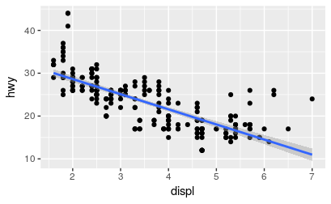

```r
g+geom_point()+geom_smooth(method="lm")
```

Now with facets

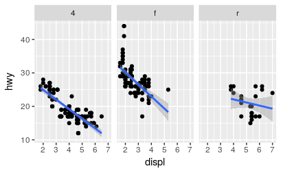

```r
g+geom_point()+geom_smooth(method="lm")+facet_grid(. ~ drv)
```

##### Modifying aesthetics

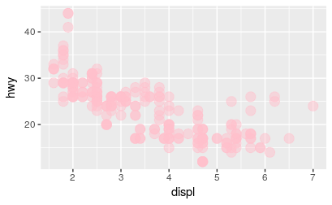

```r
g+geom_point(color="pink", size=4, alpha=1/2)
```

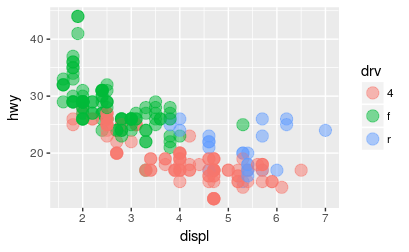

```r
g+geom_point(size=4, alpha=1/2, aes(color=drv))
```

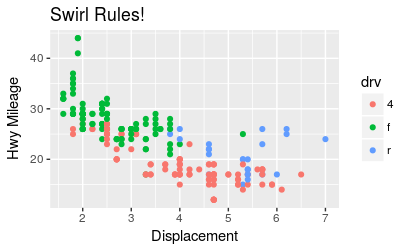

```r
g+geom_point(aes(color=drv))+labs(title="Swirl Rules!")+labs(x="Displacement", y="Hwy Mileage")
```

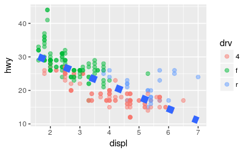

```r
g+geom_point(aes(color=drv), size=2, alpha=1/2)+geom_smooth(size=4, linetype=3, method="lm", se=FALSE)
```

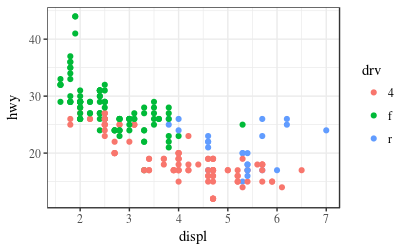

```r
g+geom_point(aes(color=drv))+theme_bw(base_family="Times")
```

#### More complicated plots

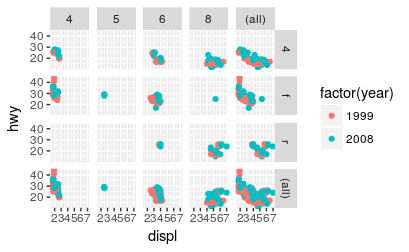

```r
g <- ggplot(data=mpg, aes(x=displ, y=hwy, color=factor(year)))
g+geom_point()+facet_grid(drv~cyl, margins=TRUE)
```